# Sta112FS 3. R/RStudio/GitHub demo

Dr. Çetinkaya-Rundel

September 1, 2015

# Housekeeping

## Announcements

- HW 1 is due next Tuesday

# From last time…

## Step 0: Load necessary packages

- In the following exercises we’ll use `dplyr` (for data wrangling) and `ggplot2` (for visualization) packages.
- Make sure the packages are installed.
- Load these packages in your markdown file:

```r
library(dplyr)
library(ggplot2)
```

## Step 1: Load data

```r
gapminder <- read.csv("https://stat.duke.edu/~mc301/data/gapminder.csv")
```

## Step 2: Subset data

- Start with the `gapminder` dataset
- Filter for cases (rows) where year is equal to 2007
- Save this new subsetted dataset as `gap07`

```r
gap07 <- gapminder %>%
  filter(year == 2007)
```

## Step 2: Explore and visualize

**Task:** Visualize the relationship between `gdpPercap` and `lifeExp`.

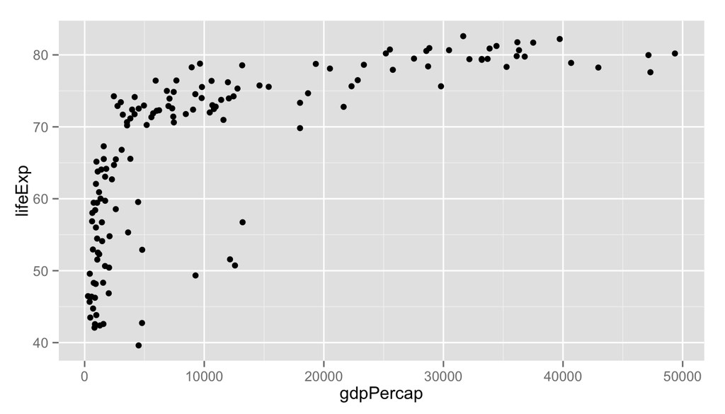

```r
qplot(x = gdpPercap, y = lifeExp, data = gap07)
```

## Step 3: Dig deeper

**Task:** Color the points by continent.

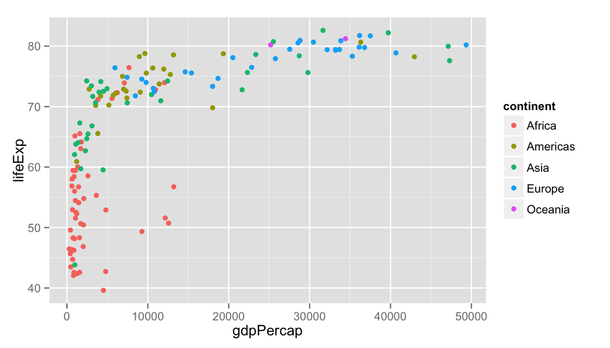

```r
qplot(x = gdpPercap, y = lifeExp, color = continent, data = gap07)
```

## Step 3: Commit and push all changes

- Stage
- Commit (with a message)
- Push

## A note on piping and layering

- The `%>%` operator in `dplyr` functions is called the pipe operator. This means you “pipe” the output of the previous line of code as the first input of the next line of code.
- The `+` operator in `ggplot2` functions is used for “layering”. This means you create the plot in layers, separated by `+`.

# What’s next?

## Update your analysis

What if you wanted to now change your analysis

- to subset for 1952
- plot life expectancy (`lifeExp`) vs. population (`pop`)
- and size the points by GPD (`gpdPercap`)
  - hint: add argument `size = gpdPercap` to your plotting code

Once you’re done, commit and push all your changes with a meaningful message.